# Version Control

Amanda D. Clark

# Reproducibility and Version Control

## Reproducibility in Science

From a [review](https://setac.onlinelibrary.wiley.com/doi/pdfdirect/10.1002/ieam.4212) on [Reproducibility and Replicability in Science](https://research.uci.edu/compliance/human-research-protections/researchers/2019%20-%20NAS%20-%20Reproducibility%20and%20Replicability%20in%20Science.pdf) by the *Committee on Replicability and Reproducibility in Science of the National Academies of Sciences, Engineering, and Medicine*:

- Reproducibility *“…obtaining consistent results using the same input data, computational steps, methods,code, and conditions of analysis.”*
- Replicability *“…obtaining consistent results across studies aimed at answering the same scientific question, each of which has obtained its own data.”*
- More about the [“Reproducibility Crisis in Science”](https://www.nature.com/articles/d41586-019-00067-3)

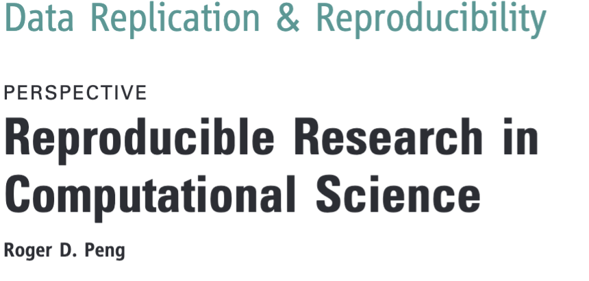

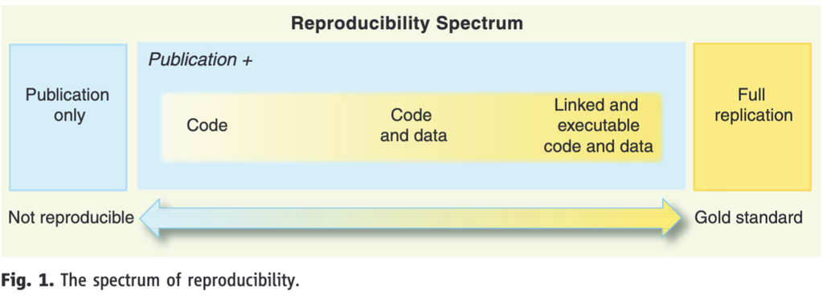

## Version Control

- How do you manage versions of documents and code?
- Do you remember the changes in each version?
- What about working code that hits a snag after edits?

  [Version Control Humor Source](https://www.reddit.com/r/ProgrammerHumor/comments/9p44w7/most_portable_version_control_system/)

[figure not shown]

[figure not shown]

[Version Control Humor Source](https://me.me/i/who-would-wir-most-advanced-version-control-system-used-to-19855373)

- Use a **Version Control System**

## Version Control & Reproducible Science

- Version Control Systems (VCS) tracks content, providing an entire history of changes
- VCS like [Git](https://git-scm.com/) allow code and text files to be shared in full
- Develop and debug portions of a project, integrate the changes into working code later

# Intro to Git

## Version Control with Git

What is [`git`](https://www.edureka.co/blog/what-is-git/)?

- Modern free and open source version control system
- Developed by the creator of Linux OS
- Manages and track change to code and text files
- Aids in reproducibility and transparency

## Basic Workflow

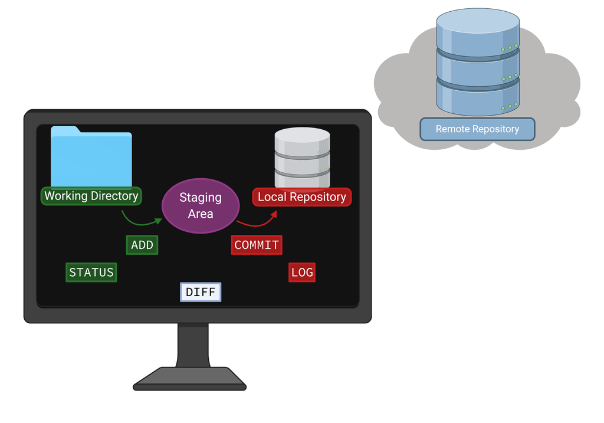

*Created with BioRender.com*

## Git Setup

Check for `git`

```
$ git --version
```

- This command should print your version of `git` (i.e., `git version 1.7.1`)
- If you reach an error (i.e.,`-bash: git: command not found`), *you need to [install `git`](https://git-scm.com/)*

Let’s personalize some basic settings in `git`

```
git config --list
```

- This command should print your current configuration settings and aliases

You may or may not have configured settings, but here are **some essential ones…**

```
git config --global user.name "Amanda D. Clark"
git config --global user.email "adc0032@auburn.edu"
git config --global core.editor "nano -w"
git config --global color.ui true
```

- Use `git config -h` for more options and settings.

**Creating a New Local Repository**

## Git command `git init`

Make a course directory

```
$ mkdir IntrotoCompBio
$ cd IntrotoCompBio
$ mkdir repo1
$ cd repo1
```

Let’s make a repository for the course…

```
$ git init
Initialized empty Git repository in /home/adc0032/IntrotoCompBio/repo1.git/
```

- `git` will now be aware of content in the working directory (tracked and untracked)

## Git command `git add`

Let’s give `git` content to track…

```
$ echo "Just keep Swimming..." > Dory.txt
$ git add Dory.txt
```

- This content is now staged to be tracked

## Git command `git status`

Let’s see what content is being tracked and/or managed…

```
$ git status

On branch master

No commits yet

Changes to be committed:
  (use "git rm --cached <file>..." to unstage)

    new file:   Dory.txt
```

- No commits, but we do have new content in the staging area .

## Git command `git commit`

Let’s commit staged content and changes to our local repository…

```
$ git commit
```

Add a summary of changes made in the commit message, save, and exit the text editor…

```
$ git commit
[master (root-commit) 8566e3b] Adding Dory's song
 1 file changed, 1 insertion(+)
 create mode 100644 Dory.txt
```

- **This was the first snapshot of the working directory stored in the local repository!**

## Git command `git diff`

Let’s see if there are any changes that haven’t been staged…

```
$ git diff
```

What happened?

```
$ echo "Just Keep Swimming, Swimming, Swimming" >> Dory.txt

$ git diff
diff --git a/Dory.txt b/Dory.txt
index 4353455..53fb00b 100644
--- a/Dory.txt
+++ b/Dory.txt
@@ -1 +1,2 @@
 Just keep Swimming...
+Just Keep Swimming, Swimming, Swimming
```

- `git` found changes to the working directory that haven’t been staged yet!
- Let’s go ahead and stage a commit.

```
$ git add Dory.txt
#We forgot to add the last part! Let's edit the file we just staged

$ echo 'What do we do? We Swim!' >> Dory.txt
```

- Run `git diff` again. What happens?
- What about if you run `git diff --staged`?
- Let’s stage and commit all changes now.

## Git command `git log`

Let’s review what `git` has done…

```
$ git log
commit e40bf73c567d1b8881795a8450667b8b30673970 (HEAD -> master)
Author: Amanda D. Clark <adc0032@auburn.edu>
Date:   Sun Aug 16 17:33:46 2020 -0500

    Added the final lines of Dory's song.

commit 8566e3bde8e7aa9428e7614f7917b2ae9d4f137e
Author: Amanda D. Clark <adc0032@auburn.edu>
Date:   Sat Aug 15 02:20:41 2020 -0500

    Adding Dory's song
```

- There are many elements here, but this is a log of changes we have made and asked `git` to track
- This is essentially your lab notebook!

## Back to the Basics

- Remember:

`git add`  
`git status`  
`git commit`

- Stage and Commit Often!
- The commit message is your friend.

# Branches in Git

## Branches

- Contribute another dimension to efficient workflows
- Useful for experimental code and new developments
- Changes to branches are independent of the “master” branch

## Git command: `git branch`

Let’s see what branches we have of our repository…

```
$ git branch
```

```
$ git branch
* master
```

- We only have one branch, our master
- The asterisk indicates current branch

Now let’s make a couple of new branches…

```
$ git branch develop
$ git branch test
```

- Run `git branch` again. How is it different from before?
- How do you get from branch to branch?

## Git command: `git checkout`

[figure not shown]

[from Imgflip Meme Generator](https://imgflip.com/memegenerator)

Let’s manipulate the develop branch…

```
$ git checkout develop
M   Dory.txt
Switched to branch 'develop'
```

- Run `git branch` again. What has changed?
- `ls` the working directory of the “develop” branch
- Edits, stages, and commits here are specific to the develop branch. Let’s test this…

Let’s sprinkle in little HTML code on our song…

- Populate Dory’s song into this html template and save as “Dory.html”

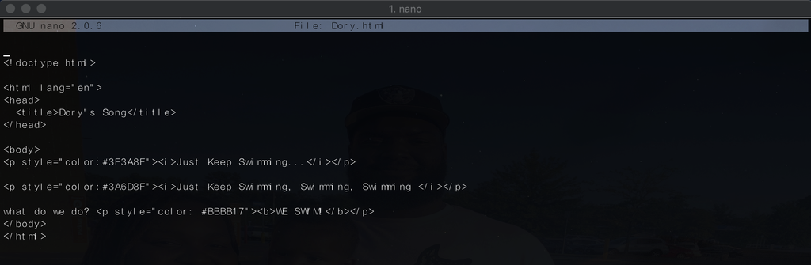

- What has changed about your directory content (Check with `ls` and `git status`)?
- Go ahead and commit these modifications to the repository (Quiz)

## Git command: `git merge`

Let’s incorporate changes in the development branch into the master branch…

```
$ git checkout master
Switched to branch 'master'

$ git merge develop
Updating e40bf73..edb4f1f
Fast-forward
 Dory.html | 16 ++++++++++++++++
 Dory.txt  |  1 +
 2 files changed, 17 insertions(+)
 create mode 100644 Dory.html
```

- We just merged our content and histories from “develop” into “master”
- What does our working directory and “master” branch look like now?
- We have new files, why don’t we have anything to commit?

## Branches: A Review

- Branches are extremely useful for making changes to existing content, particularly when publically available.
- Move between branches with `git checkout`
- Remember `git diff`? Try comparing two branches (test vs master)
- Changes on the branch didn’t work out? Use the `git branch` option `-d` to delete the branch

# Remote Repositories

## Remotes

- A version of your local repository hosted elsewhere (i.e., Internet)
- Often is read-only accessible or read-write accessible to one person (typically, the creator)
- A way to make your final products and code available to the public

## Basic Workflow

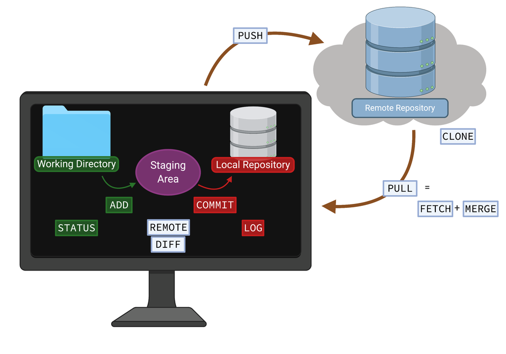

*Created with BioRender.com*

## Git command: `git clone`

Existing repositories can be copied and set up for remote access…

```
$ git clone <url or directory>
```

- Makes a local repository that is a clone of the repository at the give address
- Automatically makes a remote connection to the given address under the alias “origin”

## Git command: `git remote`

Manage remote repositories with `git remote`

```
$ git remote -v
```

- Here you are asking `git` to list your remote connections
  - `-v` means verbose, and will print the remote alias and address

```
$ git remote add <alias> <url or directory>
```

- Here you are asking `git` to set up a remote connection to a given address under a specific alias

## Git command: `git pull`

Getting content from a remote repository…

```
$ git pull <alias> <branch>
# often the command is simply origin master
$ git pull origin master
```

- `git pull` is actually two commands that incorporates remote content locally
  - `git fetch` which grabs content from the remote repository
  - `git merge` which merges remote content with your local repository
  - The two commands (`fetch merge`) are useful for when you want to inspect content before merging

## Git command: `git push`

Sending content to a remote repository…

```
$ git push origin master
```

- We are asking `git` to send a snapshot of our local repository content to the “master” branch of the remote repository named “origin”
  - Keep your local repository up-to-date with `git pull`
  - Let’s see a remote repository in action…

[video not shown]

## Collaboration with Git and GitHub

- [GitHub](https://github.com/) is one host of public and private remote code repositories ([SourceForge](https://sourceforge.net/) is another example)
  - GitHub also provides a GUI for interacting with a repository
  - GitHub repositories can be accessed in a CLI using `git clone <github url for repository>`
- Public Repositories can be Forked on GitHub
  - Forking is similar to `git clone` on the command line
  - Users can make edits or revisions to public code to submit back to the creator or to make something novel

## Best Practices for Shared Repositories

- `git pull` frequently to ensure the most up-to-date state of the repository
- Make sure to add meaningful messages for your collaborators!
- `git commit` and `git push` often to reduce merging conflicts. (Remember to `git pull` first!)

# Resources

## Git Resources

[Git Documentation](https://git-scm.com/docs)

[Learning Git](https://www.atlassian.com/git)

[*Git for Scientist* in *Bioinformatics Data Skills* by Vince Buffalo](http://2.droppdf.com/files/5aTvl/bioinformatics-data-skills.pdf) (Chapter 5)

# Acknowledgements

## Inspiration

This presentation was adapted from [Dr. Jamie Oaks’](http://phyletica.org/people/) [Intro to Git](http://phyletica.org/slides/git-intro/#/)

## Funding

This presentation was made possible by funding to Amanda Clark from NSF GRFP (1414475) and Auburn University